# Hub feature analysis

Alan Yap

11/03/2020

## Introduction

Hub features are summarised in two dataframes

1. hub_feature contains all numerical features by hubs from 2016 to 2019. Inactive hubs are denoted by 0 in status_at_Dec_19 column. This dataframe is used for cluster analysis (see the next section here)

```r
glimpse(hub_feature)
```

```
## Observations: 238
## Variables: 24
## $ HubRandomID                   <dbl> 10011, 10011, 10011, 10549, 10549, 10...
## $ year                          <dbl> 2017, 2018, 2019, 2017, 2018, 2019, 2...
## $ annual_child_prtcpnt          <dbl> 124, 405, 133, 98, 748, 964, 1878, 31...
## $ annual_adult_prtcpnt          <dbl> 484, 675, 812, 84, 1063, 1764, 292, 1...
## $ annual_DSS_prtcpnt            <dbl> 204, 150, 139, 111, 1439, 2713, 3554,...
## $ annual_referral_prtcpnt       <dbl> 188, 228, 60, 111, 248, 21, 2534, 148...
## $ annual_program_count          <int> 10, 9, 24, 8, 14, 20, 18, 21, 22, 19,...
## $ annual_activity_count         <int> 306, 354, 282, 106, 485, 550, 659, 96...
## $ annual_school_volunteer       <dbl> 0, 0, 0, 0, 0, 47, 28, 22, 13, 1, 0, ...
## $ annual_hub_volunteer          <dbl> 0, 0, 0, 1, 7, 47, 69, 106, 13, 10, 1...
## $ annual_external_volunteer     <dbl> 0, 0, 0, 1, 63, 47, 89, 156, 13, 165,...
## $ annual_prtcpnt_all            <dbl> 1000, 1458, 1144, 404, 3498, 5462, 82...
## $ avg_mthly_prtcpnt_all         <dbl> 83.3, 121.5, 95.3, 33.7, 291.5, 455.2...
## $ avg_prtcpnt_per_activity      <dbl> 3.267974, 4.118644, 4.056738, 3.81132...
## $ avg_mthly_activity_all        <dbl> 25.5, 29.5, 23.5, 8.8, 40.4, 45.8, 54...
## $ annual_volunteer_all          <dbl> 0, 0, 0, 2, 70, 141, 186, 284, 39, 17...
## $ avg_mthly_volunteer_all       <dbl> 0.0, 0.0, 0.0, 0.2, 5.8, 11.8, 15.5, ...
## $ avg_hub_annual_prtcpnt        <dbl> 8207.158, 7059.939, 6756.737, 8207.15...
## $ avg_hub_annual_activity_count <dbl> 697.3509, 614.9545, 534.8684, 697.350...
## $ avg_hub_annual_program_count  <dbl> 15.17544, 14.50000, 19.85526, 15.1754...
## $ avg_hub_prtcpnt_per_activity  <dbl> 10.99784, 10.47011, 11.11535, 10.9978...
## $ avg_hub_annual_volunteer      <dbl> 267.5789, 241.6818, 251.4868, 267.578...
## $ status_at_dec_19              <dbl> 1, 1, 1, 1, 1, 1, 1, 1, 1, 1, 1, 1, 1...
## $ years_in_operation            <dbl> 2.6, 2.6, 2.6, 2.4, 2.4, 2.4, 2.7, 2....
```

2. common_program is a mixed dataframe listing the top three most common programs by hubs from 2016 to 2019

```r
glimpse(common_program)
```

```
## Observations: 712
## Variables: 5
## $ HubRandomID   <dbl> 10011, 10011, 10011, 10011, 10011, 10011, 10011, 1001...
## $ year          <dbl> 2017, 2017, 2017, 2018, 2018, 2018, 2019, 2019, 2019,...
## $ ProgrammeName <chr> "Parent engagement", "Education and training", "Numbe...
## $ ProgrammeID   <dbl> 49, 60, 69, 49, 50, 60, 49, 52, 50, 69, 47, 62, 50, 4...
## $ n             <int> 145, 34, 34, 102, 78, 41, 37, 34, 32, 23, 12, 12, 113...
```

The next set of exploratory analysis looks at large hubs vs small hubs.

## Large hubs

Characteristics of top ten largest hubs by annual participant count in 2019

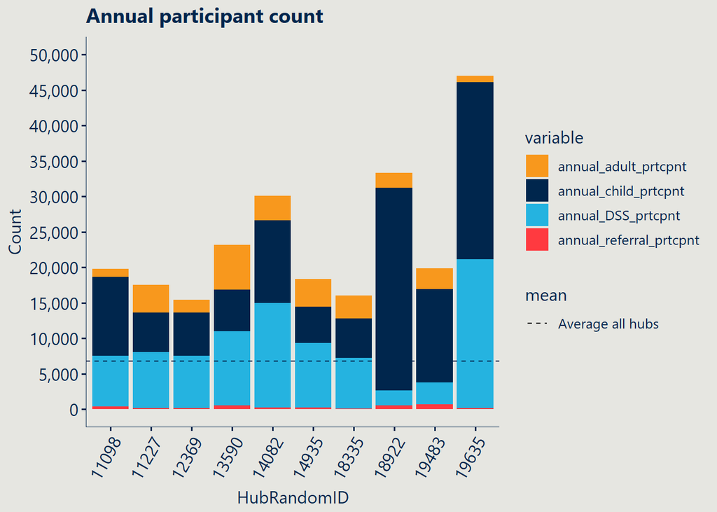

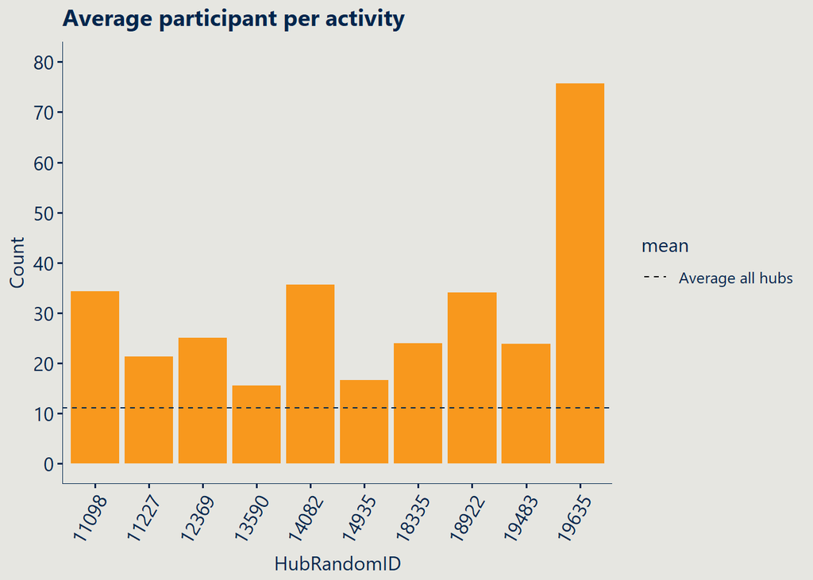

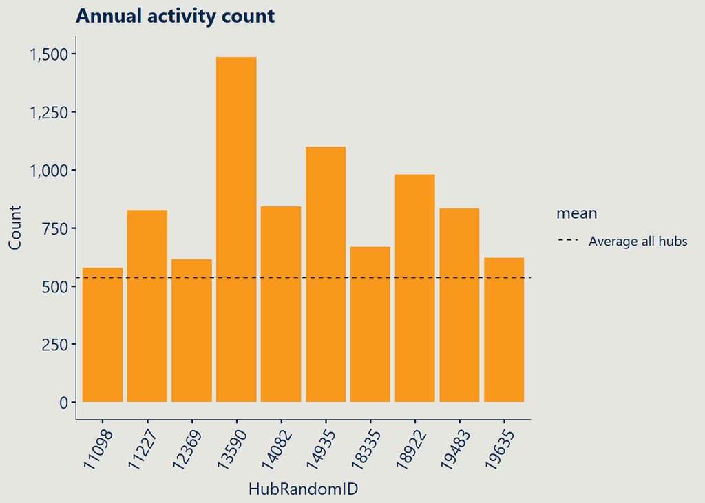

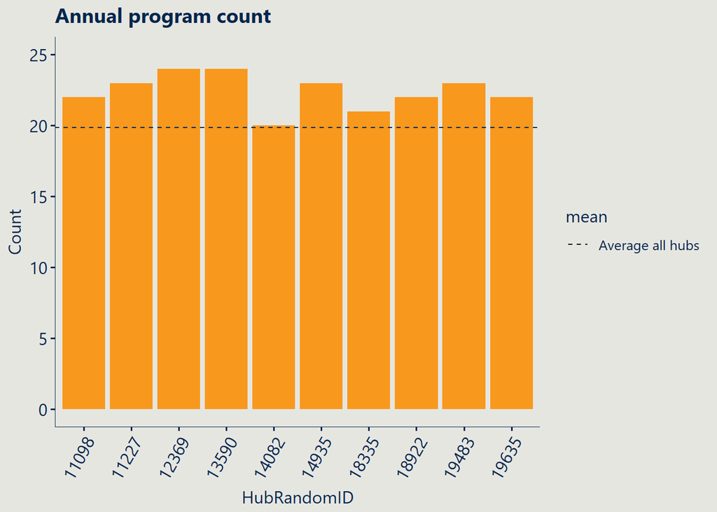

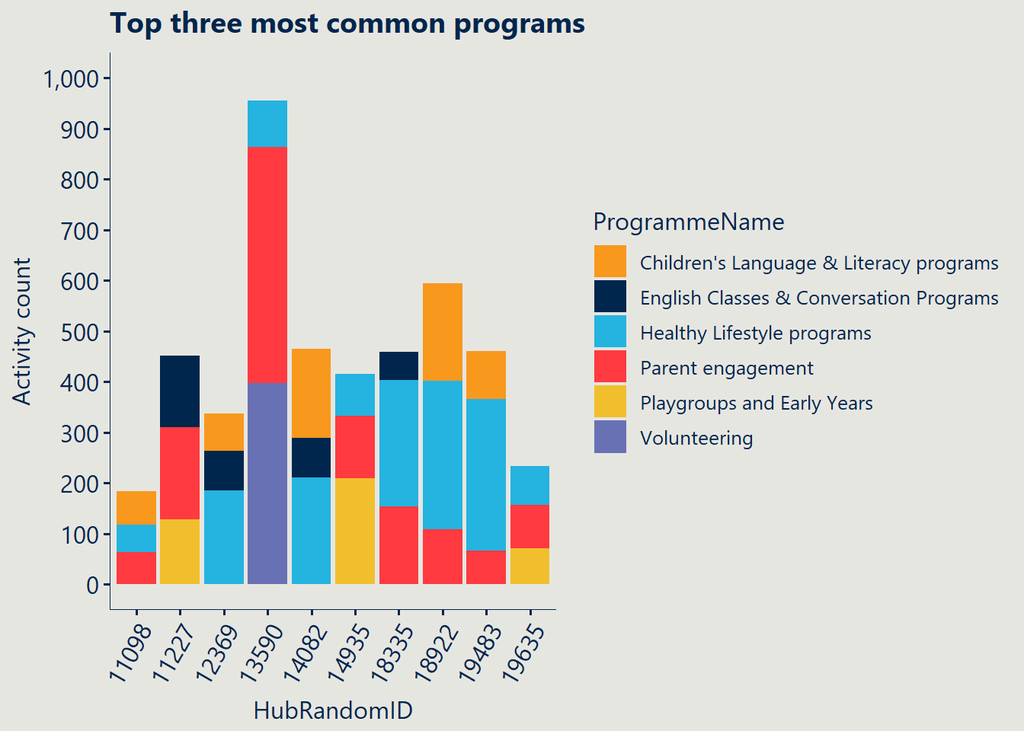

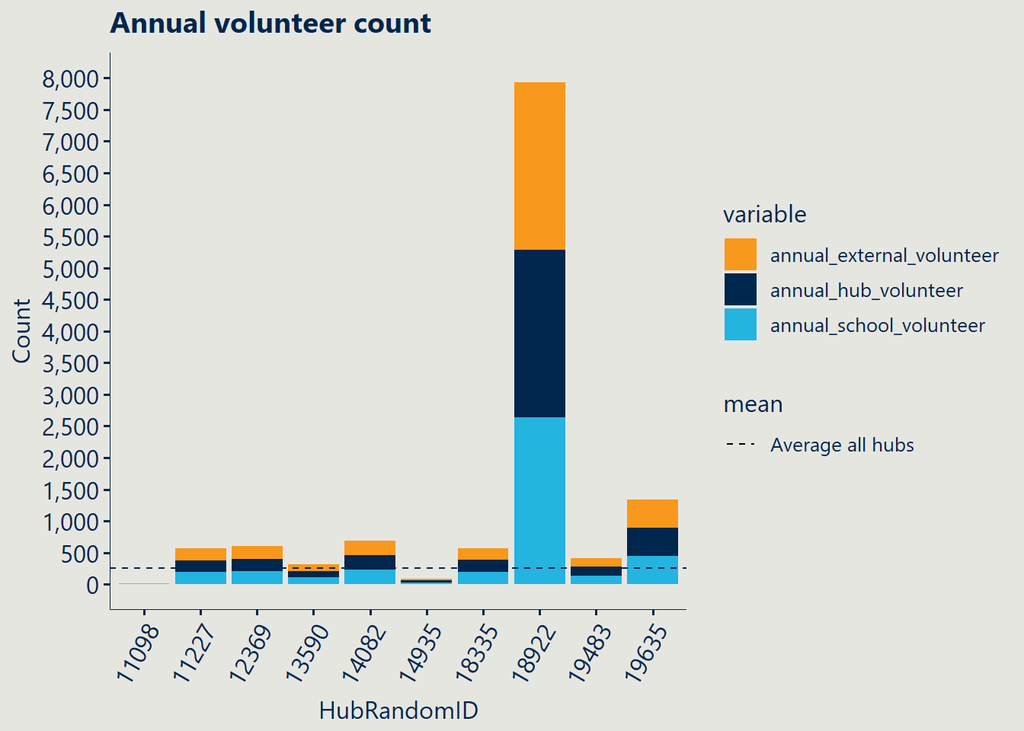

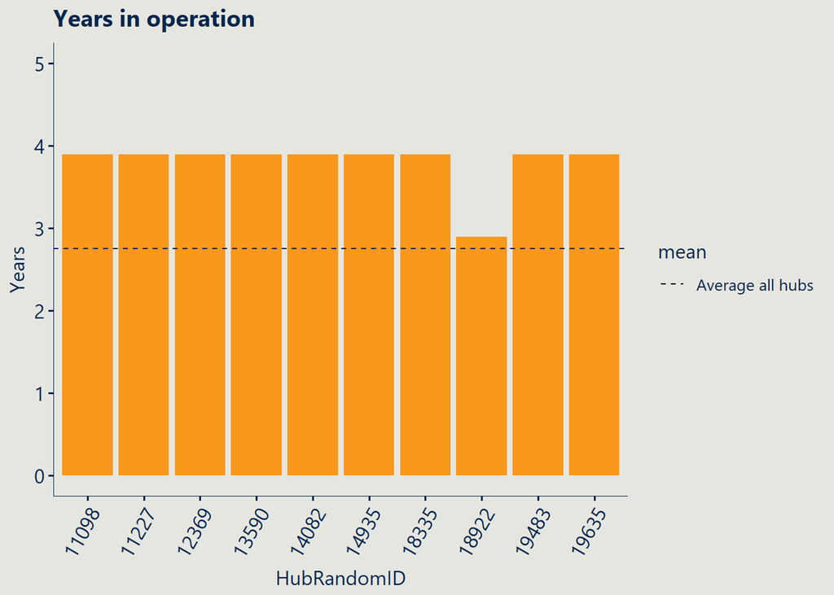

## Small participants hub

Characteristics of top ten smallest hubs by annual participant count in 2019

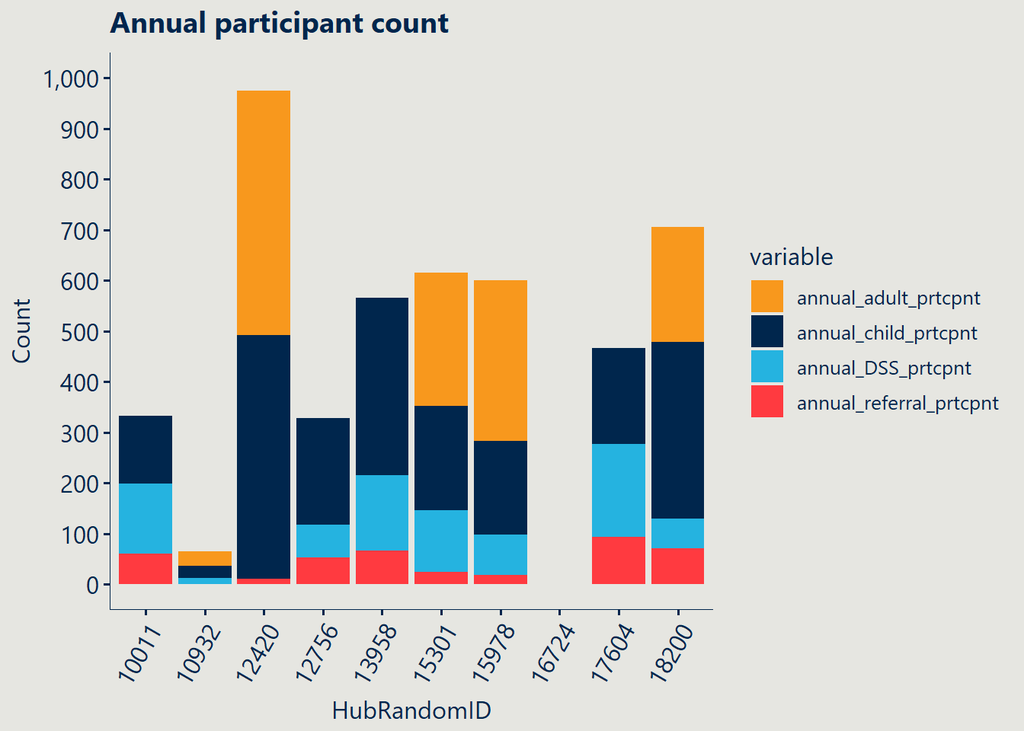

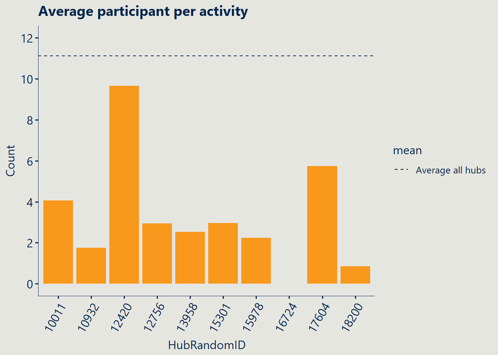

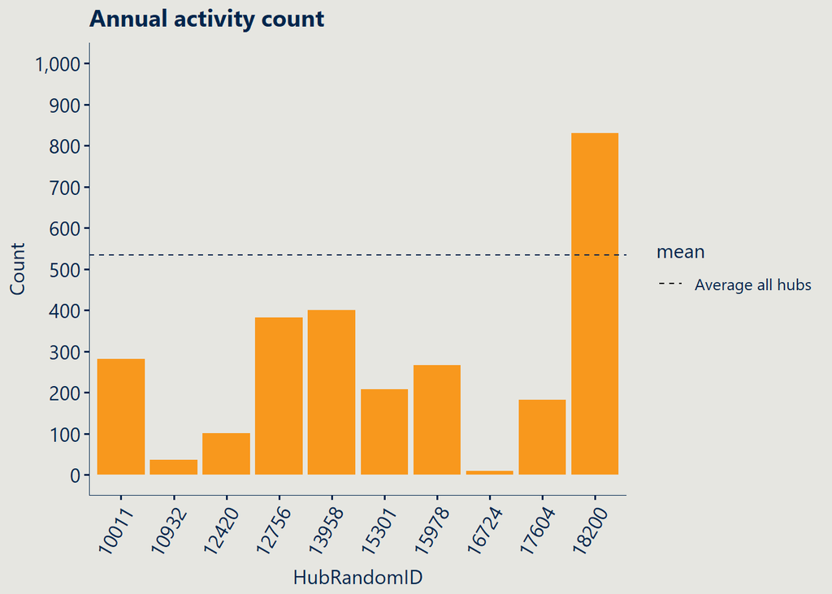

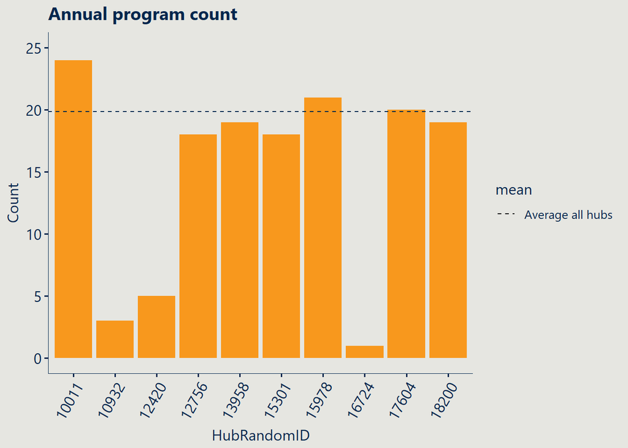

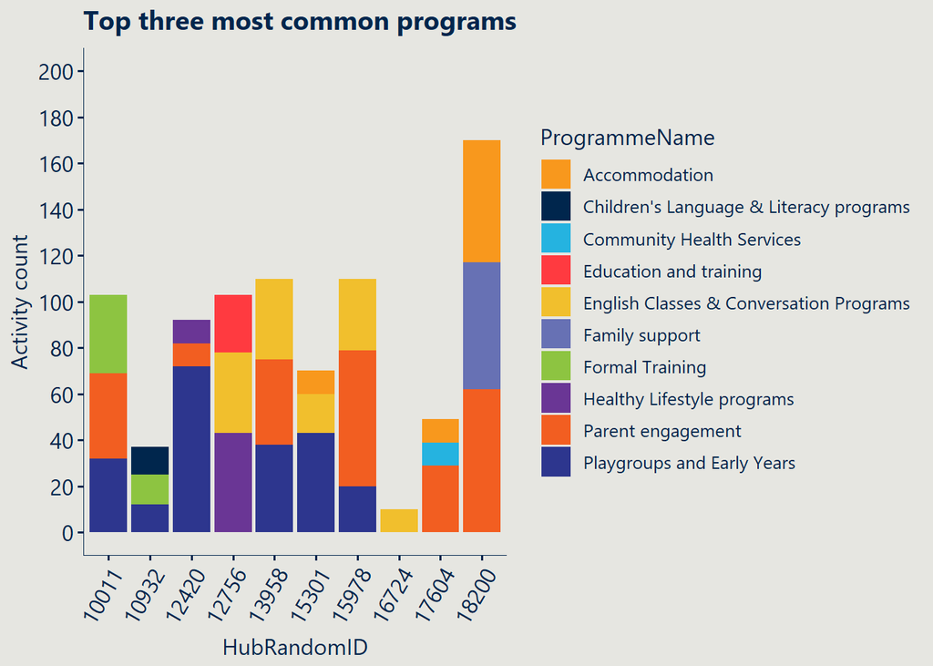

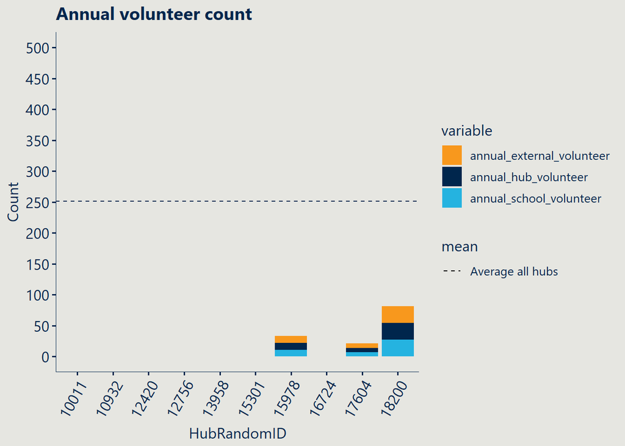

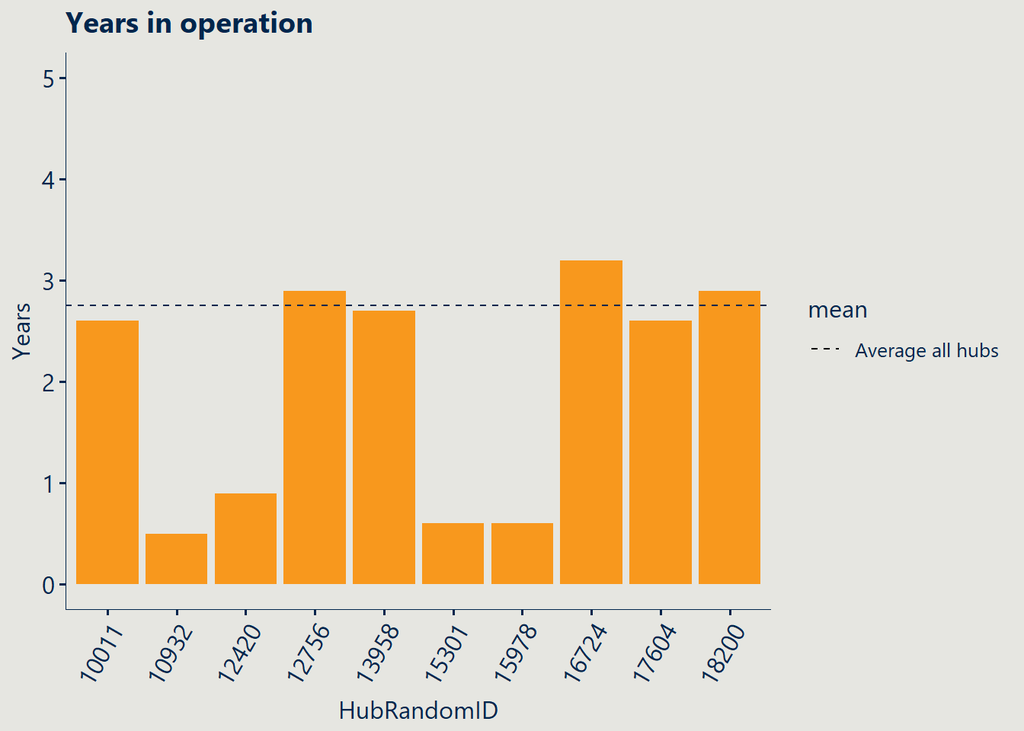

## Cluster analysis

Select six variables representing annual counts of programs, activities, participants and volunteers, hub’s operation status, and years in operation for the cluster analysis.

Bring all selected variables to the same magnitude by scaling.

Determine the optimum number of clusters in the data using the elbow method.

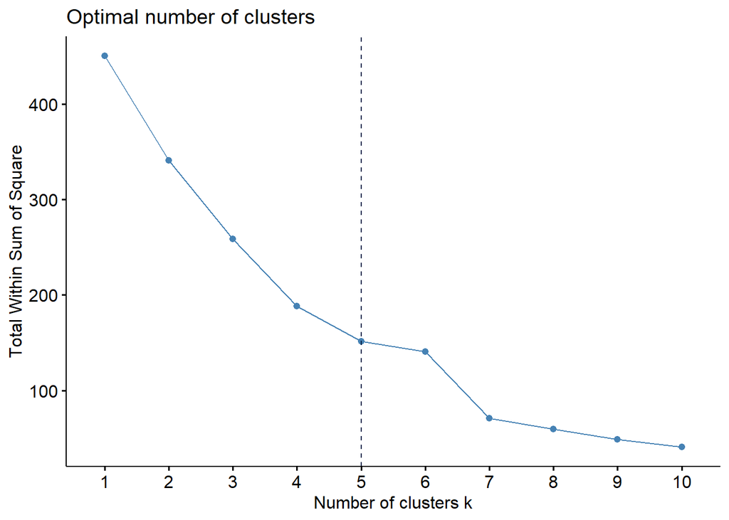

```r
fviz_nbclust(scale_data, kmeans, method = "wss") +
  geom_vline(xintercept = 5, linetype = 2)
```

Alternatively, determine the optimum number of clusters in the data using the silhouette method.

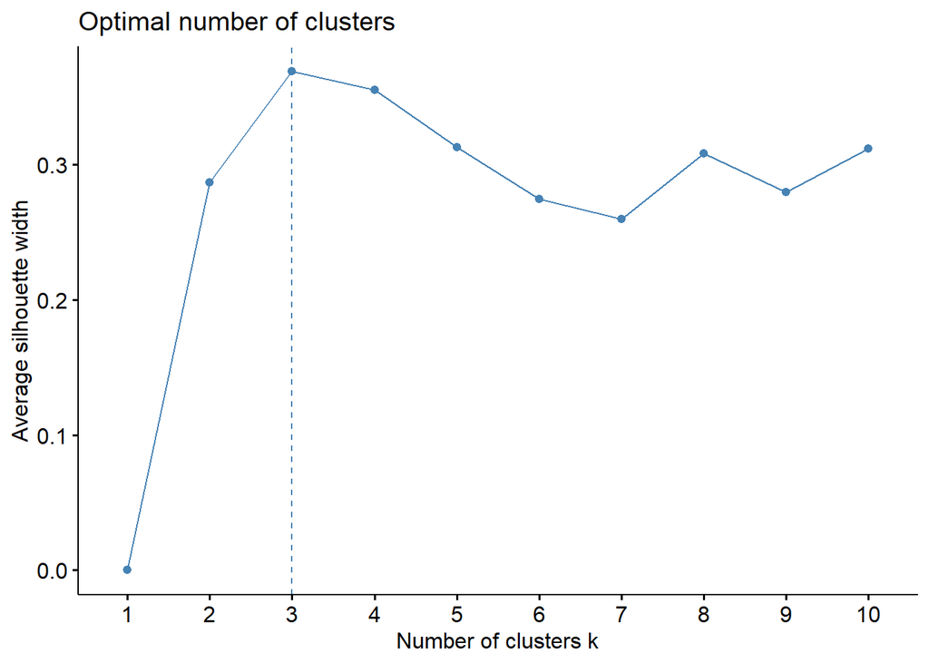

```r
fviz_nbclust(scale_data, kmeans, method = "silhouette")
```

Optimum number of clusters range from 3 to 5 clusters. Start by computing k-means with k = 5

```r
set.seed(123)

km.res <- kmeans(scale_data, 5, nstart = 25)

print(km.res)
```

```
## K-means clustering with 5 clusters of sizes 1, 15, 45, 14, 1
##
## Cluster means:
##   annual_program_count annual_activity_count annual_prtcpnt_all
## 1           -3.8135872           -1.97837863         -0.8252536
## 2           -1.0629077           -0.95715370         -0.5606052
## 3            0.2674863           -0.07824022         -0.3201483
## 4            0.5204666            1.29874538          1.4569366
## 5            0.4337856            1.67405847          3.2438925
##   annual_volunteer_all status_at_dec_19 years_in_operation
## 1           -0.2721891       -8.6030900          0.3655010
## 2           -0.2280305        0.1147079         -1.6017692
## 3           -0.1599887        0.1147079          0.2849052
## 4            0.1847043        0.1147079          0.7658632
## 5            8.3062751        0.1147079          0.1182184
##
## Clustering vector:
## 10011 10549 10813 10833 10884 10932 11098 11188 11227 11332 11419 11491 11579
##     3     3     3     3     3     2     4     3     4     4     3     3     2
## 11662 11818 11833 12369 12394 12420 12736 12756 13024 13253 13506 13516 13590
##     3     3     2     4     4     2     3     3     3     2     2     3     4
## 13748 13765 13876 13958 13966 14082 14226 14457 14819 14915 14935 14989 15120
##     3     3     3     3     3     4     4     3     3     2     4     2     3
## 15301 15830 15857 15978 15994 16050 16315 16406 16512 16538 16724 16912 16964
##     2     4     2     2     3     3     2     3     2     3     1     3     2
## 16999 17153 17182 17184 17319 17416 17534 17600 17604 18139 18154 18200 18335
##     3     3     3     3     3     3     3     3     3     3     4     3     4
## 18506 18747 18812 18922 19277 19483 19616 19635 19650 19713 19871
##     3     2     3     5     3     4     3     4     3     3     3
##
## Within cluster sum of squares by cluster:
## [1]  0.00000 34.95194 48.35427 36.43284  0.00000
##  (between_SS / total_SS =  73.4 %)
##
## Available components:
##
## [1] "cluster"      "centers"      "totss"        "withinss"     "tot.withinss"
## [6] "betweenss"    "size"         "iter"         "ifault"
```

Compute the mean of each variable by clusters

```r
aggregate(scale_data, by=list(cluster=km.res$cluster), mean)
```

```
##   cluster annual_program_count annual_activity_count annual_prtcpnt_all
## 1       1           -3.8135872           -1.97837863         -0.8252536
## 2       2           -1.0629077           -0.95715370         -0.5606052
## 3       3            0.2674863           -0.07824022         -0.3201483
## 4       4            0.5204666            1.29874538          1.4569366
## 5       5            0.4337856            1.67405847          3.2438925
##   annual_volunteer_all status_at_dec_19 years_in_operation
## 1           -0.2721891       -8.6030900          0.3655010
## 2           -0.2280305        0.1147079         -1.6017692
## 3           -0.1599887        0.1147079          0.2849052
## 4            0.1847043        0.1147079          0.7658632
## 5            8.3062751        0.1147079          0.1182184
```

Visualise k-means clusters of all hubs for k = 5

```
## Too few points to calculate an ellipse
## Too few points to calculate an ellipse
```

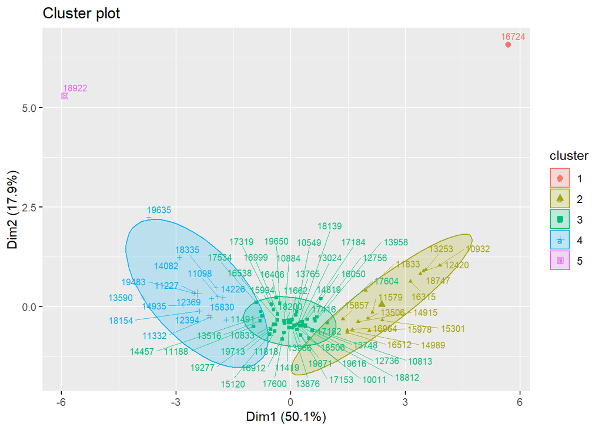

```r
cluster_data_final <- cbind(cluster_data, cluster = km.res$cluster)

fviz_cluster(km.res, cluster_data_final, ellipse.type = "norm", pointsize = 1, labelsize = 8, repel = TRUE)
```

All large hubs from the previous section belong to clusters 4 and 5 whilst all small hubs belong to clusters 1, 2 and 3. The following table summarises the clusters

[output not shown]